# Risk Factor Analysis

## Outcome Variable

**Outcome Variable:** pers_wasted624

## Predictor Variables

**Intervention Variable:** ever_stunted06

**Adjustment Set:**

- sex
- arm
- enstunt
- month
- brthmon
- vagbrth
- single
- W_gagebrth
- W_birthwt
- W_birthlen
- W_mage
- W_mhtcm
- W_meducyrs
- W_feducyrs
- W_parity
- delta_month
- delta_brthmon
- delta_vagbrth
- delta_single
- delta_W_gagebrth
- delta_W_birthwt
- delta_W_birthlen
- delta_W_mage
- delta_W_mhtcm
- delta_W_meducyrs
- delta_W_feducyrs
- delta_W_parity

## Stratifying Variables

The analysis was stratified on these variable(s):

- studyid
- country

## Data Summary

| studyid | country | ever_stunted06 | pers_wasted624 | n_cell | n |
| --- | --- | --- | --- | --- | --- |
| ki0047075b-MAL-ED | BANGLADESH | 0 | 0 | 149 | 239 |
| ki0047075b-MAL-ED | BANGLADESH | 0 | 1 | 10 | 239 |
| ki0047075b-MAL-ED | BANGLADESH | 1 | 0 | 72 | 239 |
| ki0047075b-MAL-ED | BANGLADESH | 1 | 1 | 8 | 239 |
| ki0047075b-MAL-ED | BRAZIL | 0 | 0 | 163 | 202 |
| ki0047075b-MAL-ED | BRAZIL | 0 | 1 | 2 | 202 |
| ki0047075b-MAL-ED | BRAZIL | 1 | 0 | 37 | 202 |
| ki0047075b-MAL-ED | BRAZIL | 1 | 1 | 0 | 202 |
| ki0047075b-MAL-ED | INDIA | 0 | 0 | 139 | 234 |
| ki0047075b-MAL-ED | INDIA | 0 | 1 | 15 | 234 |
| ki0047075b-MAL-ED | INDIA | 1 | 0 | 67 | 234 |
| ki0047075b-MAL-ED | INDIA | 1 | 1 | 13 | 234 |
| ki0047075b-MAL-ED | NEPAL | 0 | 0 | 194 | 234 |
| ki0047075b-MAL-ED | NEPAL | 0 | 1 | 1 | 234 |
| ki0047075b-MAL-ED | NEPAL | 1 | 0 | 38 | 234 |
| ki0047075b-MAL-ED | NEPAL | 1 | 1 | 1 | 234 |
| ki0047075b-MAL-ED | PERU | 0 | 0 | 143 | 264 |
| ki0047075b-MAL-ED | PERU | 0 | 1 | 0 | 264 |
| ki0047075b-MAL-ED | PERU | 1 | 0 | 119 | 264 |
| ki0047075b-MAL-ED | PERU | 1 | 1 | 2 | 264 |
| ki0047075b-MAL-ED | SOUTH AFRICA | 0 | 0 | 157 | 258 |
| ki0047075b-MAL-ED | SOUTH AFRICA | 0 | 1 | 2 | 258 |
| ki0047075b-MAL-ED | SOUTH AFRICA | 1 | 0 | 99 | 258 |
| ki0047075b-MAL-ED | SOUTH AFRICA | 1 | 1 | 0 | 258 |
| ki0047075b-MAL-ED | TANZANIA, UNITED REPUBLIC OF | 0 | 0 | 144 | 244 |
| ki0047075b-MAL-ED | TANZANIA, UNITED REPUBLIC OF | 0 | 1 | 0 | 244 |
| ki0047075b-MAL-ED | TANZANIA, UNITED REPUBLIC OF | 1 | 0 | 100 | 244 |
| ki0047075b-MAL-ED | TANZANIA, UNITED REPUBLIC OF | 1 | 1 | 0 | 244 |
| ki1000108-CMC-V-BCS-2002 | INDIA | 0 | 0 | 169 | 368 |
| ki1000108-CMC-V-BCS-2002 | INDIA | 0 | 1 | 11 | 368 |

[output cut: 118 more lines]

The following strata were considered:

- studyid: ki0047075b-MAL-ED, country: BANGLADESH
- studyid: ki0047075b-MAL-ED, country: BRAZIL
- studyid: ki0047075b-MAL-ED, country: INDIA
- studyid: ki0047075b-MAL-ED, country: NEPAL
- studyid: ki0047075b-MAL-ED, country: PERU
- studyid: ki0047075b-MAL-ED, country: SOUTH AFRICA
- studyid: ki0047075b-MAL-ED, country: TANZANIA, UNITED REPUBLIC OF
- studyid: ki1000108-CMC-V-BCS-2002, country: INDIA
- studyid: ki1000108-IRC, country: INDIA
- studyid: ki1000109-EE, country: PAKISTAN
- studyid: ki1000109-ResPak, country: PAKISTAN
- studyid: ki1000304-VITAMIN-A, country: INDIA
- studyid: ki1000304b-SAS-CompFeed, country: INDIA
- studyid: ki1000304b-SAS-FoodSuppl, country: INDIA
- studyid: ki1017093-NIH-Birth, country: BANGLADESH
- studyid: ki1017093b-PROVIDE, country: BANGLADESH
- studyid: ki1017093c-NIH-Crypto, country: BANGLADESH
- studyid: ki1066203-TanzaniaChild2, country: TANZANIA, UNITED REPUBLIC OF
- studyid: ki1101329-Keneba, country: GAMBIA
- studyid: ki1112895-Burkina Faso Zn, country: BURKINA FASO
- studyid: ki1112895-Guatemala BSC, country: GUATEMALA
- studyid: ki1113344-GMS-Nepal, country: NEPAL
- studyid: ki1114097-CMIN, country: BANGLADESH
- studyid: ki1114097-CMIN, country: BRAZIL
- studyid: ki1114097-CMIN, country: GUINEA-BISSAU
- studyid: ki1114097-CMIN, country: PERU
- studyid: ki1114097-CONTENT, country: PERU
- studyid: ki1119695-PROBIT, country: BELARUS
- studyid: ki1126311-ZVITAMBO, country: ZIMBABWE
- studyid: ki1135781-COHORTS, country: GUATEMALA
- studyid: ki1135781-COHORTS, country: INDIA
- studyid: ki1135781-COHORTS, country: PHILIPPINES
- studyid: ki1148112-iLiNS-DOSE, country: MALAWI
- studyid: ki1148112-iLiNS-DYAD-M, country: MALAWI
- studyid: ki1148112-LCNI-5, country: MALAWI
- studyid: kiGH5241-JiVitA-3, country: BANGLADESH
- studyid: kiGH5241-JiVitA-4, country: BANGLADESH

### Dropped Strata

Some strata were dropped due to rare outcomes:

- studyid: ki0047075b-MAL-ED, country: BRAZIL
- studyid: ki0047075b-MAL-ED, country: NEPAL
- studyid: ki0047075b-MAL-ED, country: PERU
- studyid: ki0047075b-MAL-ED, country: SOUTH AFRICA
- studyid: ki0047075b-MAL-ED, country: TANZANIA, UNITED REPUBLIC OF
- studyid: ki1112895-Burkina Faso Zn, country: BURKINA FASO
- studyid: ki1112895-Guatemala BSC, country: GUATEMALA
- studyid: ki1114097-CMIN, country: BANGLADESH
- studyid: ki1114097-CMIN, country: BRAZIL
- studyid: ki1114097-CMIN, country: PERU
- studyid: ki1114097-CONTENT, country: PERU
- studyid: ki1119695-PROBIT, country: BELARUS
- studyid: ki1148112-LCNI-5, country: MALAWI

## Methods Detail

We’re interested in the causal parameters $E[Y_a]$ for all values of $a \in \mathcal{A}$. These parameters represent the mean outcome if, possibly contrary to fact, we intervened to set all units to have $A=a$. Under the randomization and positivity assumptions, these are identified by the statistical parameters $\psi_a=E_W[E_{Y|A,W}(Y|A=a,W)]$. In addition, we’re interested in the mean of $Y$, $E[Y]$ under no intervention (the observed mean). We will estimate these parameters by using SuperLearner to fit the relevant likelihood factors – $E_{Y|A,W}(Y|A=a,W)$ and $p(A=a|W)$, and then updating our likelihood fit using a joint TMLE.

For unadjusted analyses ($W=\{\}$), initial likelihoods were estimated using Lrnr_glm to estimate the simple $E(Y|A)$ and Lrnr_mean to estimate $p(A)$. For adjusted analyses, a small library containing Lrnr_glmnet, Lrnr_xgboost, and Lrnr_mean was used.

Having estimated these parameters, we will then use the delta method to estimate relative risks and attributable risks relative to a prespecified baseline level of $A$.

# Results Detail

## Results Plots

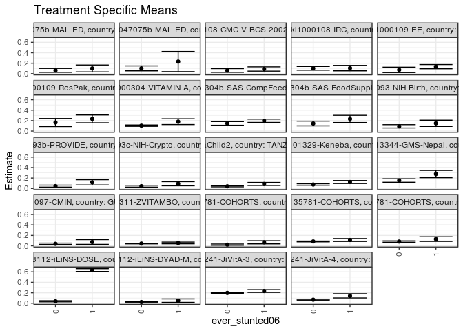

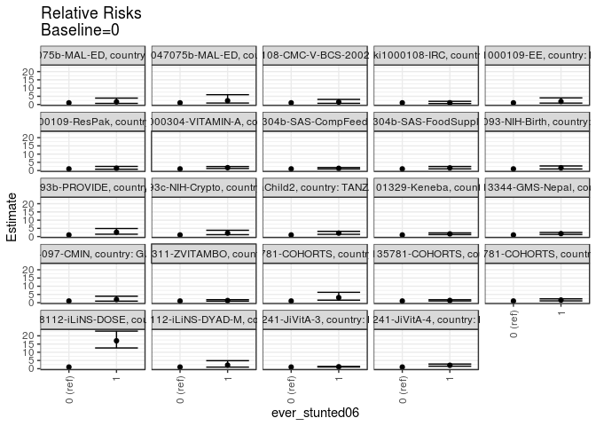

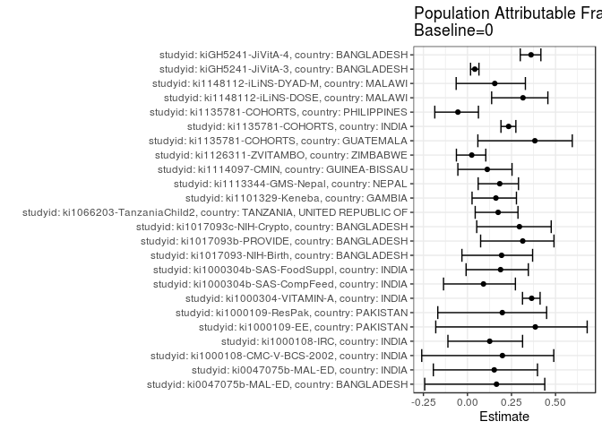

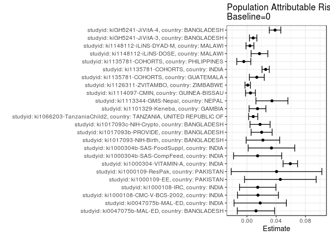

## Results Table

### Parameter: TSM

| studyid | country | intervention_level | baseline_level | estimate | ci_lower | ci_upper |
| --- | --- | --- | --- | --- | --- | --- |
| ki0047075b-MAL-ED | BANGLADESH | 0 | NA | 0.0628931 | 0.0250788 | 0.1007074 |
| ki0047075b-MAL-ED | BANGLADESH | 1 | NA | 0.1000000 | 0.0341228 | 0.1658772 |
| ki0047075b-MAL-ED | INDIA | 0 | NA | 0.1014697 | 0.0540833 | 0.1488562 |
| ki0047075b-MAL-ED | INDIA | 1 | NA | 0.2315238 | 0.0386234 | 0.4244242 |
| ki1000108-CMC-V-BCS-2002 | INDIA | 0 | NA | 0.0609848 | 0.0255218 | 0.0964477 |
| ki1000108-CMC-V-BCS-2002 | INDIA | 1 | NA | 0.0894438 | 0.0481929 | 0.1306947 |
| ki1000108-IRC | INDIA | 0 | NA | 0.1022847 | 0.0655495 | 0.1390200 |
| ki1000108-IRC | INDIA | 1 | NA | 0.1063272 | 0.0539759 | 0.1586784 |
| ki1000109-EE | PAKISTAN | 0 | NA | 0.0729167 | 0.0208366 | 0.1249967 |
| ki1000109-EE | PAKISTAN | 1 | NA | 0.1345455 | 0.0941600 | 0.1749309 |
| ki1000109-ResPak | PAKISTAN | 0 | NA | 0.1640670 | 0.0867708 | 0.2413632 |
| ki1000109-ResPak | PAKISTAN | 1 | NA | 0.2331052 | 0.1582911 | 0.3079194 |
| ki1000304-VITAMIN-A | INDIA | 0 | NA | 0.1034515 | 0.0910081 | 0.1158949 |
| ki1000304-VITAMIN-A | INDIA | 1 | NA | 0.1805262 | 0.1248585 | 0.2361940 |
| ki1000304b-SAS-CompFeed | INDIA | 0 | NA | 0.1465996 | 0.1113670 | 0.1818321 |
| ki1000304b-SAS-CompFeed | INDIA | 1 | NA | 0.1966040 | 0.1651466 | 0.2280613 |
| ki1000304b-SAS-FoodSuppl | INDIA | 0 | NA | 0.1451634 | 0.0999987 | 0.1903280 |
| ki1000304b-SAS-FoodSuppl | INDIA | 1 | NA | 0.2325766 | 0.1634334 | 0.3017197 |
| ki1017093-NIH-Birth | BANGLADESH | 0 | NA | 0.0909727 | 0.0591141 | 0.1228314 |
| ki1017093-NIH-Birth | BANGLADESH | 1 | NA | 0.1487680 | 0.0892136 | 0.2083224 |
| ki1017093b-PROVIDE | BANGLADESH | 0 | NA | 0.0440127 | 0.0249900 | 0.0630354 |
| ki1017093b-PROVIDE | BANGLADESH | 1 | NA | 0.1170104 | 0.0662725 | 0.1677484 |
| ki1017093c-NIH-Crypto | BANGLADESH | 0 | NA | 0.0429597 | 0.0252910 | 0.0606285 |
| ki1017093c-NIH-Crypto | BANGLADESH | 1 | NA | 0.0906561 | 0.0511752 | 0.1301370 |
| ki1066203-TanzaniaChild2 | TANZANIA, UNITED REPUBLIC OF | 0 | NA | 0.0408364 | 0.0308051 | 0.0508677 |
| ki1066203-TanzaniaChild2 | TANZANIA, UNITED REPUBLIC OF | 1 | NA | 0.0859212 | 0.0569868 | 0.1148555 |
| ki1101329-Keneba | GAMBIA | 0 | NA | 0.0751556 | 0.0602821 | 0.0900291 |
| ki1101329-Keneba | GAMBIA | 1 | NA | 0.1231545 | 0.0942620 | 0.1520470 |
| ki1113344-GMS-Nepal | NEPAL | 0 | NA | 0.1524409 | 0.1183669 | 0.1865148 |
| ki1113344-GMS-Nepal | NEPAL | 1 | NA | 0.2764080 | 0.2070867 | 0.3457294 |
| ki1114097-CMIN | GUINEA-BISSAU | 0 | NA | 0.0384106 | 0.0246941 | 0.0521271 |
| ki1114097-CMIN | GUINEA-BISSAU | 1 | NA | 0.0731707 | 0.0271226 | 0.1192188 |
| ki1126311-ZVITAMBO | ZIMBABWE | 0 | NA | 0.0427561 | 0.0376879 | 0.0478242 |
| ki1126311-ZVITAMBO | ZIMBABWE | 1 | NA | 0.0546359 | 0.0378270 | 0.0714449 |
| ki1135781-COHORTS | GUATEMALA | 0 | NA | 0.0218264 | 0.0098914 | 0.0337615 |
| ki1135781-COHORTS | GUATEMALA | 1 | NA | 0.0674815 | 0.0368298 | 0.0981332 |
| ki1135781-COHORTS | INDIA | 0 | NA | 0.0840532 | 0.0763576 | 0.0917487 |
| ki1135781-COHORTS | INDIA | 1 | NA | 0.1122582 | 0.0841769 | 0.1403396 |
| ki1135781-COHORTS | PHILIPPINES | 0 | NA | 0.0822183 | 0.0693808 | 0.0950557 |
| ki1135781-COHORTS | PHILIPPINES | 1 | NA | 0.1300125 | 0.0847792 | 0.1752458 |
| ki1148112-iLiNS-DOSE | MALAWI | 0 | NA | 0.0373352 | 0.0263809 | 0.0482894 |
| ki1148112-iLiNS-DOSE | MALAWI | 1 | NA | 0.6340652 | 0.6076526 | 0.6604778 |
| ki1148112-iLiNS-DYAD-M | MALAWI | 0 | NA | 0.0225989 | 0.0128025 | 0.0323952 |
| ki1148112-iLiNS-DYAD-M | MALAWI | 1 | NA | 0.0493827 | 0.0160026 | 0.0827629 |
| kiGH5241-JiVitA-3 | BANGLADESH | 0 | NA | 0.1970514 | 0.1903918 | 0.2037109 |
| kiGH5241-JiVitA-3 | BANGLADESH | 1 | NA | 0.2329613 | 0.2067016 | 0.2592210 |
| kiGH5241-JiVitA-4 | BANGLADESH | 0 | NA | 0.0680794 | 0.0595751 | 0.0765836 |
| kiGH5241-JiVitA-4 | BANGLADESH | 1 | NA | 0.1421117 | 0.1020796 | 0.1821439 |

### Parameter: E(Y)

| studyid | country | intervention_level | baseline_level | estimate | ci_lower | ci_upper |
| --- | --- | --- | --- | --- | --- | --- |
| ki0047075b-MAL-ED | BANGLADESH | NA | NA | 0.0753138 | 0.0417869 | 0.1088408 |
| ki0047075b-MAL-ED | INDIA | NA | NA | 0.1196581 | 0.0779840 | 0.1613323 |
| ki1000108-CMC-V-BCS-2002 | INDIA | NA | NA | 0.0760870 | 0.0489610 | 0.1032130 |
| ki1000108-IRC | INDIA | NA | NA | 0.1170732 | 0.0859146 | 0.1482317 |
| ki1000109-EE | PAKISTAN | NA | NA | 0.1185984 | 0.0856546 | 0.1515422 |
| ki1000109-ResPak | PAKISTAN | NA | NA | 0.2045455 | 0.1511224 | 0.2579685 |
| ki1000304-VITAMIN-A | INDIA | NA | NA | 0.1627604 | 0.1476839 | 0.1778369 |
| ki1000304b-SAS-CompFeed | INDIA | NA | NA | 0.1612426 | 0.1416314 | 0.1808538 |
| ki1000304b-SAS-FoodSuppl | INDIA | NA | NA | 0.1787565 | 0.1404842 | 0.2170288 |
| ki1017093-NIH-Birth | BANGLADESH | NA | NA | 0.1128405 | 0.0854611 | 0.1402198 |
| ki1017093b-PROVIDE | BANGLADESH | NA | NA | 0.0641447 | 0.0446535 | 0.0836359 |
| ki1017093c-NIH-Crypto | BANGLADESH | NA | NA | 0.0609418 | 0.0434802 | 0.0784034 |
| ki1066203-TanzaniaChild2 | TANZANIA, UNITED REPUBLIC OF | NA | NA | 0.0494534 | 0.0397554 | 0.0591514 |
| ki1101329-Keneba | GAMBIA | NA | NA | 0.0896333 | 0.0777184 | 0.1015482 |
| ki1113344-GMS-Nepal | NEPAL | NA | NA | 0.1866438 | 0.1550166 | 0.2182711 |
| ki1114097-CMIN | GUINEA-BISSAU | NA | NA | 0.0432802 | 0.0298127 | 0.0567476 |
| ki1126311-ZVITAMBO | ZIMBABWE | NA | NA | 0.0438186 | 0.0394817 | 0.0481556 |
| ki1135781-COHORTS | GUATEMALA | NA | NA | 0.0353591 | 0.0233199 | 0.0473983 |
| ki1135781-COHORTS | INDIA | NA | NA | 0.1096840 | 0.1017209 | 0.1176470 |
| ki1135781-COHORTS | PHILIPPINES | NA | NA | 0.0779833 | 0.0679723 | 0.0879943 |
| ki1148112-iLiNS-DOSE | MALAWI | NA | NA | 0.0545229 | 0.0388484 | 0.0701975 |
| ki1148112-iLiNS-DYAD-M | MALAWI | NA | NA | 0.0267431 | 0.0169662 | 0.0365200 |
| kiGH5241-JiVitA-3 | BANGLADESH | NA | NA | 0.2056324 | 0.1980748 | 0.2131900 |
| kiGH5241-JiVitA-4 | BANGLADESH | NA | NA | 0.1065428 | 0.0957758 | 0.1173098 |

### Parameter: RR

| studyid | country | intervention_level | baseline_level | estimate | ci_lower | ci_upper |
| --- | --- | --- | --- | --- | --- | --- |
| ki0047075b-MAL-ED | BANGLADESH | 0 | 0 | 1.000000 | 1.0000000 | 1.000000 |
| ki0047075b-MAL-ED | BANGLADESH | 1 | 0 | 1.590000 | 0.6517059 | 3.879204 |
| ki0047075b-MAL-ED | INDIA | 0 | 0 | 1.000000 | 1.0000000 | 1.000000 |
| ki0047075b-MAL-ED | INDIA | 1 | 0 | 2.281703 | 0.8747897 | 5.951338 |
| ki1000108-CMC-V-BCS-2002 | INDIA | 0 | 0 | 1.000000 | 1.0000000 | 1.000000 |
| ki1000108-CMC-V-BCS-2002 | INDIA | 1 | 0 | 1.466658 | 0.6965455 | 3.088220 |
| ki1000108-IRC | INDIA | 0 | 0 | 1.000000 | 1.0000000 | 1.000000 |
| ki1000108-IRC | INDIA | 1 | 0 | 1.039521 | 0.5636387 | 1.917194 |
| ki1000109-EE | PAKISTAN | 0 | 0 | 1.000000 | 1.0000000 | 1.000000 |
| ki1000109-EE | PAKISTAN | 1 | 0 | 1.845195 | 0.8503012 | 4.004162 |
| ki1000109-ResPak | PAKISTAN | 0 | 0 | 1.000000 | 1.0000000 | 1.000000 |
| ki1000109-ResPak | PAKISTAN | 1 | 0 | 1.420793 | 0.8035288 | 2.512235 |
| ki1000304-VITAMIN-A | INDIA | 0 | 0 | 1.000000 | 1.0000000 | 1.000000 |
| ki1000304-VITAMIN-A | INDIA | 1 | 0 | 1.745032 | 1.2530420 | 2.430197 |
| ki1000304b-SAS-CompFeed | INDIA | 0 | 0 | 1.000000 | 1.0000000 | 1.000000 |
| ki1000304b-SAS-CompFeed | INDIA | 1 | 0 | 1.341095 | 0.9804474 | 1.834403 |
| ki1000304b-SAS-FoodSuppl | INDIA | 0 | 0 | 1.000000 | 1.0000000 | 1.000000 |
| ki1000304b-SAS-FoodSuppl | INDIA | 1 | 0 | 1.602171 | 1.0421545 | 2.463121 |
| ki1017093-NIH-Birth | BANGLADESH | 0 | 0 | 1.000000 | 1.0000000 | 1.000000 |
| ki1017093-NIH-Birth | BANGLADESH | 1 | 0 | 1.635303 | 0.9599210 | 2.785869 |
| ki1017093b-PROVIDE | BANGLADESH | 0 | 0 | 1.000000 | 1.0000000 | 1.000000 |
| ki1017093b-PROVIDE | BANGLADESH | 1 | 0 | 2.658560 | 1.4403004 | 4.907268 |
| ki1017093c-NIH-Crypto | BANGLADESH | 0 | 0 | 1.000000 | 1.0000000 | 1.000000 |
| ki1017093c-NIH-Crypto | BANGLADESH | 1 | 0 | 2.110257 | 1.1592685 | 3.841373 |
| ki1066203-TanzaniaChild2 | TANZANIA, UNITED REPUBLIC OF | 0 | 0 | 1.000000 | 1.0000000 | 1.000000 |
| ki1066203-TanzaniaChild2 | TANZANIA, UNITED REPUBLIC OF | 1 | 0 | 2.104035 | 1.3863789 | 3.193185 |
| ki1101329-Keneba | GAMBIA | 0 | 0 | 1.000000 | 1.0000000 | 1.000000 |
| ki1101329-Keneba | GAMBIA | 1 | 0 | 1.638660 | 1.2071505 | 2.224418 |
| ki1113344-GMS-Nepal | NEPAL | 0 | 0 | 1.000000 | 1.0000000 | 1.000000 |
| ki1113344-GMS-Nepal | NEPAL | 1 | 0 | 1.813215 | 1.2981370 | 2.532666 |
| ki1114097-CMIN | GUINEA-BISSAU | 0 | 0 | 1.000000 | 1.0000000 | 1.000000 |
| ki1114097-CMIN | GUINEA-BISSAU | 1 | 0 | 1.904962 | 0.9239299 | 3.927658 |
| ki1126311-ZVITAMBO | ZIMBABWE | 0 | 0 | 1.000000 | 1.0000000 | 1.000000 |
| ki1126311-ZVITAMBO | ZIMBABWE | 1 | 0 | 1.277852 | 0.9192891 | 1.776271 |
| ki1135781-COHORTS | GUATEMALA | 0 | 0 | 1.000000 | 1.0000000 | 1.000000 |
| ki1135781-COHORTS | GUATEMALA | 1 | 0 | 3.091734 | 1.5204989 | 6.286633 |
| ki1135781-COHORTS | INDIA | 0 | 0 | 1.000000 | 1.0000000 | 1.000000 |
| ki1135781-COHORTS | INDIA | 1 | 0 | 1.335562 | 1.0239426 | 1.742016 |
| ki1135781-COHORTS | PHILIPPINES | 0 | 0 | 1.000000 | 1.0000000 | 1.000000 |
| ki1135781-COHORTS | PHILIPPINES | 1 | 0 | 1.581309 | 1.0808992 | 2.313388 |
| ki1148112-iLiNS-DOSE | MALAWI | 0 | 0 | 1.000000 | 1.0000000 | 1.000000 |
| ki1148112-iLiNS-DOSE | MALAWI | 1 | 0 | 16.983050 | 12.6166723 | 22.860544 |
| ki1148112-iLiNS-DYAD-M | MALAWI | 0 | 0 | 1.000000 | 1.0000000 | 1.000000 |
| ki1148112-iLiNS-DYAD-M | MALAWI | 1 | 0 | 2.185185 | 0.9789204 | 4.877857 |
| kiGH5241-JiVitA-3 | BANGLADESH | 0 | 0 | 1.000000 | 1.0000000 | 1.000000 |
| kiGH5241-JiVitA-3 | BANGLADESH | 1 | 0 | 1.182236 | 1.0512785 | 1.329507 |
| kiGH5241-JiVitA-4 | BANGLADESH | 0 | 0 | 1.000000 | 1.0000000 | 1.000000 |
| kiGH5241-JiVitA-4 | BANGLADESH | 1 | 0 | 2.087442 | 1.5369417 | 2.835121 |

### Parameter: PAR

| studyid | country | intervention_level | baseline_level | estimate | ci_lower | ci_upper |
| --- | --- | --- | --- | --- | --- | --- |
| ki0047075b-MAL-ED | BANGLADESH | 0 | NA | 0.0124207 | -0.0131019 | 0.0379434 |
| ki0047075b-MAL-ED | INDIA | 0 | NA | 0.0181884 | -0.0175976 | 0.0539744 |
| ki1000108-CMC-V-BCS-2002 | INDIA | 0 | NA | 0.0151022 | -0.0128752 | 0.0430796 |
| ki1000108-IRC | INDIA | 0 | NA | 0.0147884 | -0.0100817 | 0.0396586 |
| ki1000109-EE | PAKISTAN | 0 | NA | 0.0456817 | -0.0032462 | 0.0946096 |
| ki1000109-ResPak | PAKISTAN | 0 | NA | 0.0404785 | -0.0214783 | 0.1024352 |
| ki1000304-VITAMIN-A | INDIA | 0 | NA | 0.0593089 | 0.0494220 | 0.0691958 |
| ki1000304b-SAS-CompFeed | INDIA | 0 | NA | 0.0146430 | -0.0182411 | 0.0475272 |
| ki1000304b-SAS-FoodSuppl | INDIA | 0 | NA | 0.0335931 | 0.0017683 | 0.0654179 |
| ki1017093-NIH-Birth | BANGLADESH | 0 | NA | 0.0218677 | -0.0010314 | 0.0447668 |
| ki1017093b-PROVIDE | BANGLADESH | 0 | NA | 0.0201320 | 0.0057776 | 0.0344865 |
| ki1017093c-NIH-Crypto | BANGLADESH | 0 | NA | 0.0179821 | 0.0042685 | 0.0316957 |
| ki1066203-TanzaniaChild2 | TANZANIA, UNITED REPUBLIC OF | 0 | NA | 0.0086170 | 0.0024119 | 0.0148222 |
| ki1101329-Keneba | GAMBIA | 0 | NA | 0.0144777 | 0.0030205 | 0.0259349 |
| ki1113344-GMS-Nepal | NEPAL | 0 | NA | 0.0342030 | 0.0123514 | 0.0560545 |
| ki1114097-CMIN | GUINEA-BISSAU | 0 | NA | 0.0048696 | -0.0019086 | 0.0116478 |
| ki1126311-ZVITAMBO | ZIMBABWE | 0 | NA | 0.0010626 | -0.0026077 | 0.0047329 |
| ki1135781-COHORTS | GUATEMALA | 0 | NA | 0.0135327 | 0.0033193 | 0.0237460 |
| ki1135781-COHORTS | INDIA | 0 | NA | 0.0256308 | 0.0206487 | 0.0306128 |
| ki1135781-COHORTS | PHILIPPINES | 0 | NA | -0.0042349 | -0.0137836 | 0.0053137 |
| ki1148112-iLiNS-DOSE | MALAWI | 0 | NA | 0.0171877 | 0.0057488 | 0.0286267 |
| ki1148112-iLiNS-DYAD-M | MALAWI | 0 | NA | 0.0041442 | -0.0012704 | 0.0095588 |
| kiGH5241-JiVitA-3 | BANGLADESH | 0 | NA | 0.0085810 | 0.0035263 | 0.0136358 |
| kiGH5241-JiVitA-4 | BANGLADESH | 0 | NA | 0.0384634 | 0.0306133 | 0.0463135 |

### Parameter: PAF

| studyid | country | intervention_level | baseline_level | estimate | ci_lower | ci_upper |
| --- | --- | --- | --- | --- | --- | --- |
| ki0047075b-MAL-ED | BANGLADESH | 0 | NA | 0.1649196 | -0.2426794 | 0.4388261 |
| ki0047075b-MAL-ED | INDIA | 0 | NA | 0.1520030 | -0.1936345 | 0.3975553 |
| ki1000108-CMC-V-BCS-2002 | INDIA | 0 | NA | 0.1984858 | -0.2595776 | 0.4899680 |
| ki1000108-IRC | INDIA | 0 | NA | 0.1263179 | -0.1109091 | 0.3128866 |
| ki1000109-EE | PAKISTAN | 0 | NA | 0.3851799 | -0.1799604 | 0.6796471 |
| ki1000109-ResPak | PAKISTAN | 0 | NA | 0.1978948 | -0.1683838 | 0.4493481 |
| ki1000304-VITAMIN-A | INDIA | 0 | NA | 0.3643939 | 0.3125053 | 0.4123663 |
| ki1000304b-SAS-CompFeed | INDIA | 0 | NA | 0.0908136 | -0.1357730 | 0.2721962 |
| ki1000304b-SAS-FoodSuppl | INDIA | 0 | NA | 0.1879267 | -0.0077698 | 0.3456214 |
| ki1017093-NIH-Birth | BANGLADESH | 0 | NA | 0.1937932 | -0.0314351 | 0.3698398 |
| ki1017093b-PROVIDE | BANGLADESH | 0 | NA | 0.3138531 | 0.0747565 | 0.4911636 |
| ki1017093c-NIH-Crypto | BANGLADESH | 0 | NA | 0.2950696 | 0.0526185 | 0.4754734 |
| ki1066203-TanzaniaChild2 | TANZANIA, UNITED REPUBLIC OF | 0 | NA | 0.1742455 | 0.0439521 | 0.2867821 |
| ki1101329-Keneba | GAMBIA | 0 | NA | 0.1615215 | 0.0261252 | 0.2780939 |
| ki1113344-GMS-Nepal | NEPAL | 0 | NA | 0.1832526 | 0.0608682 | 0.2896883 |
| ki1114097-CMIN | GUINEA-BISSAU | 0 | NA | 0.1125131 | -0.0544330 | 0.2530269 |
| ki1126311-ZVITAMBO | ZIMBABWE | 0 | NA | 0.0242497 | -0.0627054 | 0.1040898 |
| ki1135781-COHORTS | GUATEMALA | 0 | NA | 0.3827212 | 0.0590500 | 0.5950548 |
| ki1135781-COHORTS | INDIA | 0 | NA | 0.2336784 | 0.1902118 | 0.2748118 |
| ki1135781-COHORTS | PHILIPPINES | 0 | NA | -0.0543058 | -0.1854514 | 0.0623312 |
| ki1148112-iLiNS-DOSE | MALAWI | 0 | NA | 0.3152389 | 0.1372818 | 0.4564879 |
| ki1148112-iLiNS-DYAD-M | MALAWI | 0 | NA | 0.1549637 | -0.0640709 | 0.3289109 |
| kiGH5241-JiVitA-3 | BANGLADESH | 0 | NA | 0.0417300 | 0.0175816 | 0.0652848 |
| kiGH5241-JiVitA-4 | BANGLADESH | 0 | NA | 0.3610140 | 0.2998381 | 0.4168447 |